CATH LAB · WARD TEACHING MODULE

# 認識支架失敗 Stent Failure

四種分型 × OCT / IVUS 影像特徵 × 臨床表現 — 給導管室技術員、病房專科護理師與護理師的入門教材

教學圖卡：CardioVisual｜整理：謝慕揚 MD, PhD, FESC（讀書會共筆）

### 先建立一個觀念

冠狀動脈放的支架 (stent) 不是放了就一勞永逸。**支架失敗 (stent failure)** 泛指支架放置後該段血管再次出問題 —— 可能**突然塞住（血栓）**，也可能**慢慢變窄（再狹窄）**。臨床上用**光學同調斷層掃描 (Optical Coherence Tomography, OCT)** 或**血管內超音波 (Intravascular Ultrasound, IVUS)** 這兩種血管內影像，把支架看清楚、找出是哪一型、為什麼失敗。

1

Stent Thrombosis

支架血栓

很快 · 急性

2

In-Stent Restenosis

支架內再狹窄

慢 · 數月～數年

3

Neoatherosclerosis

新生動脈硬化

晚 · 多 > 1 年

4

Mechanical Failure

機械性失敗

地基問題

## ① 支架血栓 Stent Thrombosis

支架段的**急性血栓阻塞**，是四型裡最兇、最急的一種。

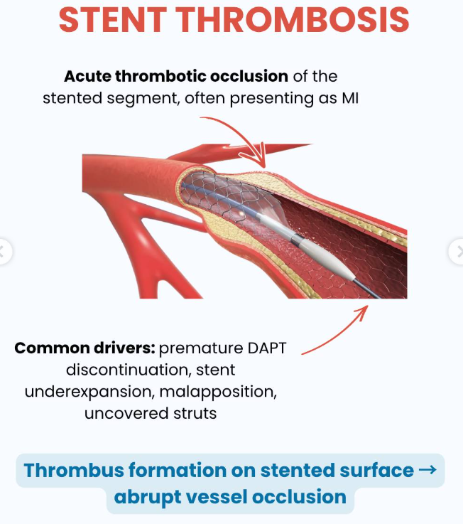

CardioVisual：血栓在支架表面形成 → 血管急性阻塞

#### 臨床表現

- 常以**急性心肌梗塞 (Myocardial Infarction, MI)** 表現，多為 ST 段上升型 (STEMI)
- 突發劇烈胸痛、冒冷汗、血壓下降，嚴重可猝死
- 誘因：**雙重抗血小板治療 (Dual Antiplatelet Therapy, DAPT) 過早停藥**、擴張不全、貼壁不良、strut 未被內皮覆蓋

#### OCT 看到什麼

- 管腔內**血栓**：紅血栓訊號強、後方陰影衰減；白血栓（血小板為主）衰減較少
- 常同時看到元兇：貼壁不良、strut 未覆蓋、擴張不全、邊緣剝離

#### IVUS 看到什麼

- 管腔內**充填缺損 (filling defect)**、飄動低回音團塊
- 血栓回音較雜、邊界不清
- 穿透深，適合大血管、可揪出背後的擴張不全

## ② 支架內再狹窄 In-Stent Restenosis (ISR)

支架內膜過度增生 (neointimal hyperplasia)，管腔**漸進性再變窄**。

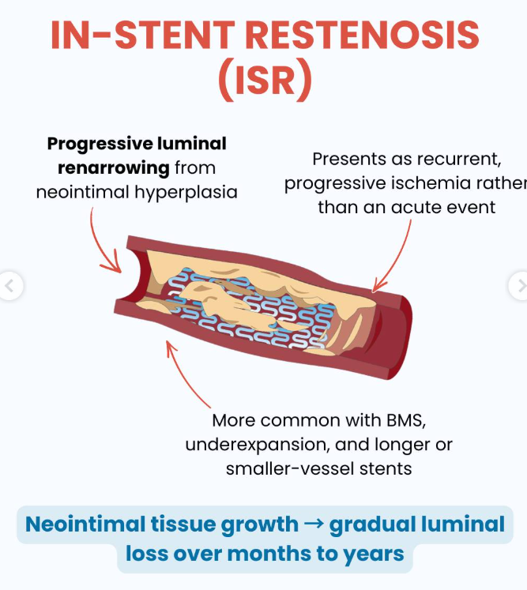

CardioVisual：內膜增生 → 數月至數年逐步管腔喪失

#### 臨床表現

- 多為**反覆、漸進的胸悶／運動時心絞痛**，而非突發事件
- 較常見於**裸金屬支架 (Bare-Metal Stent, BMS)**、擴張不全、以及較長或較小血管的支架

#### OCT 看到什麼

- 支架內一圈增厚的**內膜組織**
- 均質高訊號＝典型平滑肌增生；亦可為異質或分層型態
- 可精準量測內膜厚度與最小管腔面積

#### IVUS 看到什麼

- 支架金屬亮環仍在，內側被**低回音增生組織**填滿
- 管腔面積縮小
- 比較「支架面積 vs 內膜面積」，分辨是增生還是當初沒撐開

## ③ 支架內新生動脈硬化 Neoatherosclerosis

支架內膜裡**長出新的粥狀斑塊**，是連結「再狹窄」與「血栓」的橋樑。

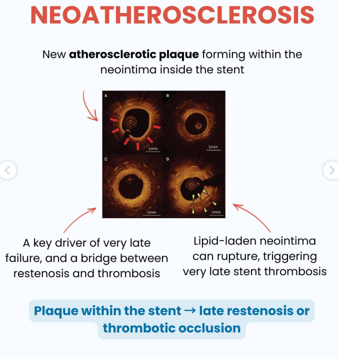

CardioVisual：支架內斑塊 → 晚期再狹窄或血栓阻塞（圖中即 OCT 影像）

#### 臨床表現

- 是**晚期／極晚期支架失敗**的關鍵原因
- 斑塊若破裂 → 可引發**極晚期支架血栓 (very late stent thrombosis)**，表現為急性冠心症 (Acute Coronary Syndrome, ACS)

#### OCT 看到什麼（此型強項）

- **脂質性內膜**：訊號低、邊界模糊的區域
- **巨噬細胞**：一顆顆明亮亮點 (bright spots)
- 類似**薄纖維帽粥狀瘤 (Thin-Cap Fibroatheroma, TCFA)**、鈣化、甚至內膜破裂

#### IVUS 看到什麼

- 內膜內出現**衰減斑塊 (attenuated plaque)** 或低回音區
- 對脂質／巨噬細胞敏感度不如 OCT（解析度較低）
- 優點：穿透深、不需大量顯影劑

## ④ 機械性失敗 Underexpansion / Malapposition / Fracture

支架本身**沒撐開、沒貼壁、或斷掉** —— 為其他三型「鋪路」的地基問題。

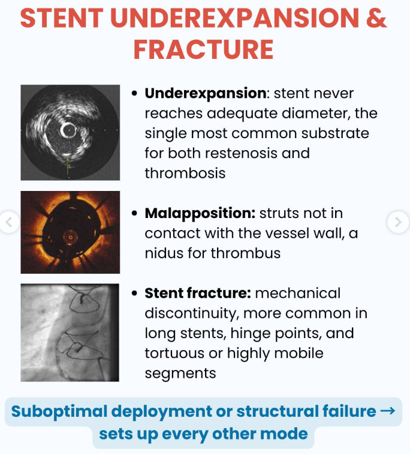

CardioVisual：不理想的置放或結構失敗 → 誘發其他所有失敗型態

#### 三種機械問題

- **擴張不全 (Underexpansion)**：支架沒達足夠直徑，是再狹窄與血栓**最常見的地基**
- **貼壁不良 (Malapposition)**：strut 沒貼到血管壁，成為血栓溫床
- **支架斷裂 (Fracture)**：好發於長支架、轉折點 (hinge point)、扭曲或高活動度血管段

#### OCT 看到什麼

- **擴張不全**：最小支架面積 (Minimal Stent Area, MSA) 明顯小於參考段
- **貼壁不良**：strut 與血管壁之間有空隙、後方有血流訊號
- **斷裂**：strut 排列中斷、該有金屬影的地方缺損

#### IVUS 看到什麼

- **擴張不全**：MSA 偏小，可與參考血管對比
- **貼壁不良**：strut 後方見血流斑點 (blood speckle)
- 對擴張不全與血管尺寸判斷特別實用，是打大 balloon 前後的好幫手

## 支架血栓：依「發生時間」分類

⏱️

急性

Acute

< 24 小時

📅

亞急性

Subacute

24 小時 – 30 天

🕐

晚期

Late

30 天 – 1 年

⏳

極晚期

Very late

> 1 年

💡 病人回來胸痛時，**「距離放支架多久」**就是第一條鑑別線索：越早越偏機械／血栓問題，越晚越要想到新生動脈硬化。

## OCT 與 IVUS 怎麼分工？

### OCT（光學同調斷層）

- 解析度極高（約 10–15 微米）
- 看**血栓、strut 覆蓋、貼壁、新生動脈硬化、巨噬細胞**最清楚
- 需沖顯影劑把血液推開 → 腎功能差者要留意

### IVUS（血管內超音波）

- 穿透深、看得到血管全層與斑塊負荷
- 適合**大血管、開口病灶、擴張不全與尺寸評估**
- 不需大量顯影劑，腎功能不佳時較友善

## 小測驗 · 自我檢核

點選你認為正確的答案，會立即顯示對錯與說明。

Q1. 病人放完支架後 3 小時突發胸痛、心電圖 ST 段上升，最可能是哪一型？

正確：急性支架血栓多在放置後短時間內發生，常以 STEMI 表現。ISR 與新生動脈硬化都是「慢性／晚期」的過程。

Q2. 想看清楚「strut 有沒有貼壁、有沒有被內皮覆蓋、有沒有巨噬細胞」，哪一種影像最合適？

正確：OCT 解析度約 10–15 微米，對 strut 覆蓋、貼壁、血栓與新生動脈硬化的細節最清楚。

Q3. 下列何者是「其他三型的地基」，若沒處理好會誘發血栓與再狹窄？

正確：擴張不全是再狹窄與血栓「最常見的地基（substrate）」；不理想的置放會鋪路給其他失敗型態。

Q4. 支架放置滿 2 年後才發生的支架血栓，最需要優先想到的機轉是？

正確：> 1 年屬「極晚期」，脂質性新生內膜破裂是極晚期支架血栓的重要成因。

### 一句話帶走 Take Home

✅ Stent failure 分四型：**血栓（急）、再狹窄（慢）、新生動脈硬化（晚）、機械性（地基）**。

✅ **OCT** 看細節（血栓／覆蓋／脂質），**IVUS** 看尺寸與擴張、對腎友善。

✅ 病人回來胸痛時，**「距離放支架多久」**就是第一條鑑別線索。